```python
import pandas as pd
pd.set_option('display.expand_frame_repr', False)

import matplotlib
import matplotlib.pyplot as plt
font = {'size' : 20}
matplotlib.rc('font', **font)

import seaborn as sns

from pylab import rcParams
rcParams["figure.figsize"] = 30,16

import sklearn
from sklearn import metrics

import numpy as np
import scipy

import datetime as dt
from datetime import date

from collections import OrderedDict

from sklearn.preprocessing import PolynomialFeatures
from sklearn.model_selection import train_test_split
from sklearn.linear_model import LinearRegression

import warnings
warnings.filterwarnings("ignore")

import sys
sys.path.insert(0, "../")
import functions
```

# Zusammenfassung der Daten

```python
#Daten aus CSV-Datei laden
df = pd.read_csv("data.csv", index_col=0, parse_dates=True)
df.index.freq = "D"

#Sonnenaufgang/Sonnenuntergang laden und Tagesstunden berechnen
df["tagesstunden"] = round((pd.to_timedelta(
    pd.to_datetime(df["sonnenuntergang"]).dt.strftime("%H:%M:%S")).dt.total_seconds() -
    pd.to_timedelta(pd.to_datetime(df["sonnenaufgang"]).dt.strftime("%H:%M:%S")).dt.total_seconds()) / 3600, 1)

df = df.drop(["sonnenaufgang", "sonnenuntergang"], axis=1)

#Temporär für Analysen verwendete Spalten berechnen
df["temperatur_gruppiert"] = 5 * round(df["temperatur"]/5)
```

Das Merkmal enthält eine zusammenfassende Beschreibung des Wetters in Textform. Da das Merkmal fast 50 unterschiedliche Ausprägungen annehmen kann, werden ähnliche Merkmalsausprägungen in fünf entsprechenden Gruppen zusammengefasst:  
1. Regen  
2. Bewölkt  
3. Klar  
4. Schnee  
5. Nebel  
Zusätzlich muss das Wetter in allen Städten zu einem einzigen Merkmal zusammengefasst werden. Dafür wird der Modus der Werte der vier Städte jedes Tages gewählt. In wenigen Fällen, in denen der Modus nicht eindeutig ist, wird stellvertretend der Wert von Stuttgart für alle vier Städte gewählt.

```python
df_ = pd.read_csv("Datenbeschaffung/kalender.csv", index_col=0, parse_dates=True, usecols=[0])
df_ = df_.join(pd.read_csv("Datenbeschaffung/stuttgart.csv", index_col=0, parse_dates=True, usecols=[0,4], squeeze=True).rename("stuttgart"))
df_ = df_.join(pd.read_csv("Datenbeschaffung/freiburg.csv", index_col=0, parse_dates=True, usecols=[0,4], squeeze=True).rename("freiburg"))
df_ = df_.join(pd.read_csv("Datenbeschaffung/mannheim.csv", index_col=0, parse_dates=True, usecols=[0,4], squeeze=True).rename("mannheim"))
df_ = df_.join(pd.read_csv("Datenbeschaffung/ulm.csv", index_col=0, parse_dates=True, usecols=[0,4], squeeze=True).rename("ulm"))


df_ = df_.replace("Patchy rain possible", "regen")
df_ = df_.replace("Patchy light rain", "regen")
df_ = df_.replace("Light rain", "regen")
df_ = df_.replace("Moderate rain at times", "regen")
df_ = df_.replace("Moderate rain", "regen")
df_ = df_.replace("Heavy rain at times", "regen")
df_ = df_.replace("Heavy rain", "regen")
df_ = df_.replace("Light freezing rain", "regen")
df_ = df_.replace("Moderate or heavy freezing rain", "regen")
df_ = df_.replace("Light rain shower", "regen")
df_ = df_.replace("Moderate or heavy rain shower", "regen")
df_ = df_.replace("Torrential rain shower", "regen")
df_ = df_.replace("Patchy light rain with thunder", "regen")
df_ = df_.replace("Moderate or heavy rain with thunder", "regen")
df_ = df_.replace("Thundery outbreaks possible", "regen")
df_ = df_.replace("Patchy freezing drizzle possible", "regen")
df_ = df_.replace("Patchy light drizzle", "regen")
df_ = df_.replace("Light drizzle", "regen")
df_ = df_.replace("Freezing drizzle", "regen")
df_ = df_.replace("Heavy freezing drizzle", "regen")

df_ = df_.replace("Patchy snow possible", "schnee")
df_ = df_.replace("Patchy sleet possible", "schnee")
df_ = df_.replace("Blowing snow", "schnee")
df_ = df_.replace("Blizzard", "schnee")
df_ = df_.replace("Light sleet", "schnee")
df_ = df_.replace("Moderate or heavy sleet", "schnee")
df_ = df_.replace("Patchy light snow", "schnee")
df_ = df_.replace("Light snow", "schnee")
df_ = df_.replace("Patchy moderate snow", "schnee")
df_ = df_.replace("Moderate snow", "schnee")
df_ = df_.replace("Patchy heavy snow", "schnee")
df_ = df_.replace("Heavy snow", "schnee")
df_ = df_.replace("Light sleet showers", "schnee")
df_ = df_.replace("Moderate or heavy sleet showers", "schnee")
df_ = df_.replace("Light snow showers", "schnee")
df_ = df_.replace("Moderate or heavy snow showers", "schnee")
df_ = df_.replace("Patchy light snow with thunder", "schnee")
df_ = df_.replace("Moderate or heavy snow with thunder", "schnee")

df_ = df_.replace("Partly cloudy", "bewoelkt")
df_ = df_.replace("Cloudy", "bewoelkt")
df_ = df_.replace("Overcast", "bewoelkt")

df_ = df_.replace("Mist", "nebel")
df_ = df_.replace("Fog", "nebel")
df_ = df_.replace("Freezing fog", "nebel")

df_ = df_.replace("Ice pellets", "eis")
df_ = df_.replace("Light showers of ice pellets", "eis")
df_ = df_.replace("Moderate or heavy showers of ice pellets", "eis")

df_ = df_.replace("Sunny", "klar")

df_['n'] = [len(set(v[pd.notna(v)].tolist())) for v in df_.values]

df_["wetter"] = df_.mode(axis=1)[0]
df_.loc[df_['n'] == 4, 'wetter'] = df_[df_['n'] == 4]["stuttgart"]

df["wetter"] = df_["wetter"]
```

```python
#Aufteilung in zwei DataFrames für weitere Analysen
df_arbeitstag = df[df["arbeitstag"] == 1]
df_arbeitsfreiertag = df[df["arbeitstag"] == 0]

print(df)
print()
print(df.describe().transpose())
```

```
            verbrauch     monat   wochentag  arbeitstag  temperatur  tagesstunden  temperatur_gruppiert    wetter
datum
2015-01-01     126197    Januar  Donnerstag           0        -2.5           8.4                  -0.0     nebel
2015-01-02     147085    Januar     Freitag           1        -0.0           8.4                  -0.0     regen
2015-01-03     141426    Januar     Samstag           0         1.2           8.4                   0.0     regen
2015-01-04     132446    Januar     Sonntag           0        -0.2           8.4                  -0.0    schnee
2015-01-05     152611    Januar      Montag           1        -0.5           8.4                  -0.0      klar
...               ...       ...         ...         ...         ...           ...                   ...       ...
2021-12-27     153489  Dezember      Montag           1         5.7           8.3                   5.0  bewoelkt
2021-12-28     155182  Dezember    Dienstag           1         8.2           8.3                  10.0     regen
2021-12-29     153611  Dezember    Mittwoch           1         8.7           8.3                  10.0     regen
2021-12-30     148126  Dezember  Donnerstag           1        11.3           8.3                  10.0     regen
2021-12-31     137327  Dezember     Freitag           1        10.7           8.3                  10.0  bewoelkt

[2557 rows x 8 columns]

                       count           mean           std       min       25%       50%       75%       max
verbrauch             2557.0  169329.063355  27116.871253  102469.0  147992.0  175584.0  190001.0  231190.0
arbeitstag            2557.0       0.687133      0.463751       0.0       0.0       1.0       1.0       1.0
temperatur            2557.0      11.706492      7.845246     -10.0       5.2      11.2      18.0      32.1
tagesstunden          2557.0      12.254634      2.700311       8.3       9.7      12.3      14.9      16.2
temperatur_gruppiert  2557.0      11.656238      7.988422     -10.0       5.0      10.0      20.0      30.0
```

# Datenanalyse

Das Histogramm zeigt die Verteilung der einzelnen (zusammengefassten) Merkmalsausprägungen. Das Wetter ist meist klar/bewölkt oder regnerisch, Schnee und Nebel treten jahreszeitbedingt eher selten auf.

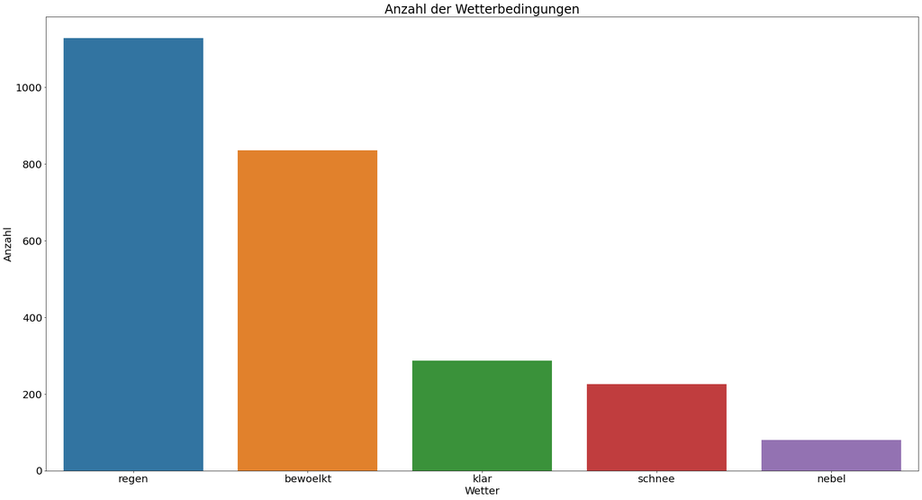

```python
#Boxplot erstellen
sns.countplot(data=df, x="wetter", order=df["wetter"].value_counts().index);

#Achsen und Layout
plt.title("Anzahl der Wetterbedingungen")
plt.ylabel("Anzahl")
plt.xlabel("Wetter")

plt.show()
```

Es ist deutlich erkennbar, dass das Wetter einer bestimmten Saisonalität folgt. Klares und bewölktes Wetter gibt es über das ganze Jahr gleichmäßig verteilt, wobei es im Sommer etwas weniger bewölktes Wetter gibt als im Winter. Im Sommer gibt es häufig regnerisches Wetter (wobei hierrunter auch „mögliches Regenwetter“ zusammengefasst wurde). Schnee gibt es selbstverständlich nur im Winter, auch Nebel gibt es vorrangig in kalten Monaten.

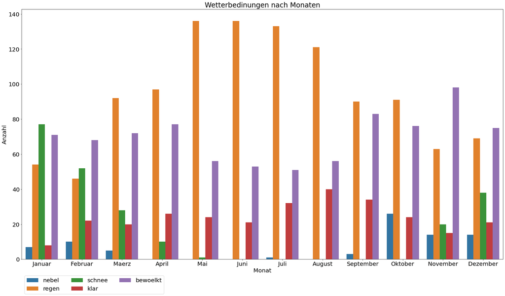

```python
#Boxplot erstellen
sns.countplot(data=df, x="monat", hue="wetter");

#Achsen und Layout
plt.title("Wetterbedinungen nach Monaten")
plt.ylabel("Anzahl")
plt.xlabel("Monat")

#Legende einfügen
handles, labels = plt.gca().get_legend_handles_labels()
by_label = OrderedDict(zip(labels, handles))
plt.legend(by_label.values(), by_label.keys(), loc="lower left", bbox_to_anchor=(0,-0.15), ncol=3)

plt.show()
```

# Zusammenhangsanalyse

## Stromverbrauch nach Wetterbedingung (Boxplot)

Die Boxplots zeigen, dass sich klares, bewölktes und verregnetes Wetter beim Stromverbrauch kaum voneinander unterscheiden. Bei nebligem oder verschneitem Wetter ist der Stromverbrauch leicht höher, dies lässt sich allerdings auf die Tatsache zurückführen, dass diese Wetterbedingungen vorrangig im Winter beziehungsweise in kälteren Monaten auftreten, wo der Stromverbrauch aufgrund der niedrigeren Temperatur höher ist.

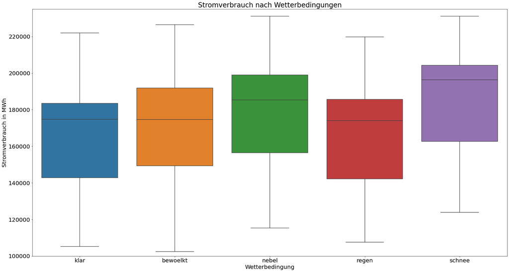

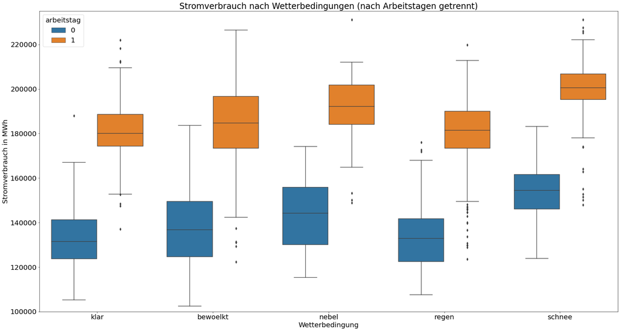

```python
#Boxplot erstellen
sns.boxplot(data=df, x="wetter", y="verbrauch", order=["klar", "bewoelkt", "nebel", "regen", "schnee"]);

#Achsen und Layout
plt.title("Stromverbrauch nach Wetterbedingungen")
plt.ylabel("Stromverbrauch in MWh")
plt.ylim(100000, 235000)
plt.xlabel("Wetterbedingung")

plt.show()

#Boxplot erstellen
sns.boxplot(data=df, x="wetter", y="verbrauch", hue="arbeitstag", order=["klar", "bewoelkt", "nebel", "regen", "schnee"]);

#Achsen und Layout
plt.title("Stromverbrauch nach Wetterbedingungen (nach Arbeitstagen getrennt)")
plt.ylabel("Stromverbrauch in MWh")
plt.ylim(100000, 235000)
plt.xlabel("Wetterbedingung")

plt.show()
```

Dieser Zusammenhang zeigt sich auch, wenn das Auftreten der Wetterbedingungen und der damit verbundenen Temperatur analysiert wird. So tritt (wie oben beschrieben) Regenwetter beispielsweise vorwiegend bei höheren Temperaturen und Schnee/Nebel bei niedrigeren Temperaturen auf.

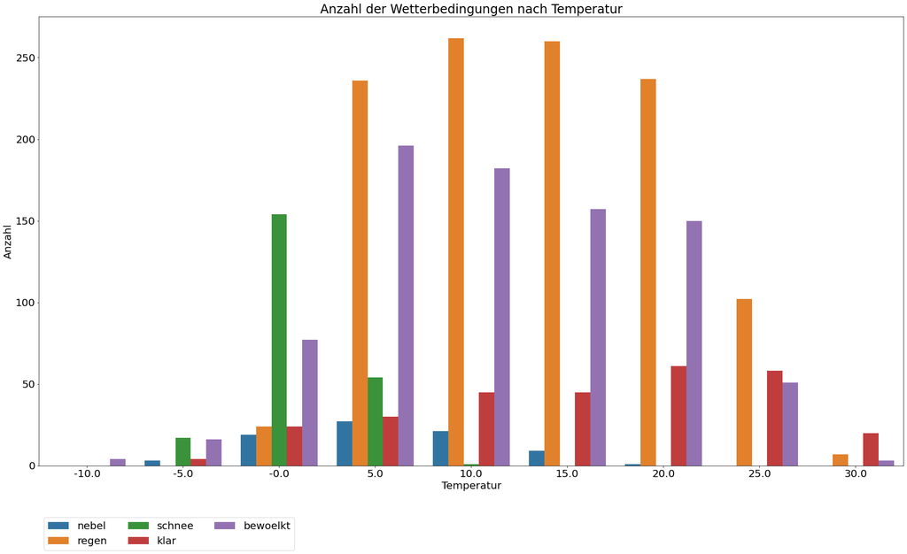

```python
#Boxplot erstellen
sns.countplot(data=df, x="temperatur_gruppiert", hue="wetter");

#Achsen und Layout
plt.title("Anzahl der Wetterbedingungen nach Temperatur")
plt.ylabel("Anzahl")
plt.xlabel("Temperatur")

#Legende einfügen
handles, labels = plt.gca().get_legend_handles_labels()
by_label = OrderedDict(zip(labels, handles))
plt.legend(by_label.values(), by_label.keys(), loc="lower left", bbox_to_anchor=(0,-0.2), ncol=3)

plt.show()
```

## Stromverbrauch nach Wetterbedingung und Temperatur (Boxplot)

Die Boxplots zeigen den Stromverbrauch nach Wetterbedingungen und der gerundeten Temperatur. Hier ist zu erkennen, dass der Stromverbrauch bei jeder Wetterbedingung dem temperatur-bedingten Muster folgt. Von niedrigen Temperaturen aus gesehen fällt der Stromverbrauch mit steigender Temperatur bis zum Kipppunkt bei etwa 20-25°C. Ab dann steigt der Stromverbrauch mit der Temperatur an. Dieser Zusammenhang zeigt sich in etwa gleich bei allen Wetterbedingungen.

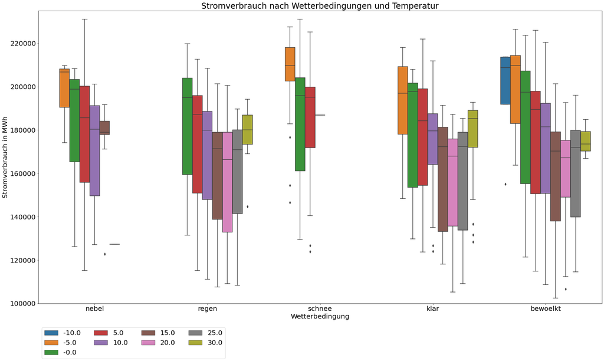

```python
#Boxplot erstellen
sns.boxplot(data=df, x="wetter", y="verbrauch", hue="temperatur_gruppiert");

#Achsen und Layout
plt.title("Stromverbrauch nach Wetterbedingungen und Temperatur")
plt.ylabel("Stromverbrauch in MWh")
plt.ylim(100000, 235000)
plt.xlabel("Wetterbedingung")

#Legende einfügen
handles, labels = plt.gca().get_legend_handles_labels()
by_label = OrderedDict(zip(labels, handles))
plt.legend(by_label.values(), by_label.keys(), loc="lower left", bbox_to_anchor=(0,-0.2), ncol=4)

plt.show()
```

Die oben beschriebenen Effekte zeigen sich auch bei den statistischen Kennzahlen für jede Wetterbedingung.

```python
print("Klar:")
print(df[df["wetter"] == "klar"][["verbrauch", "temperatur"]].describe().transpose())
print("\n")

print("Bewölkt:")
print(df[df["wetter"] == "bewoelkt"][["verbrauch", "temperatur"]].describe().transpose())
print("\n")

print("Nebel:")
print(df[df["wetter"] == "nebel"][["verbrauch", "temperatur"]].describe().transpose())
print("\n")

print("Regen:")
print(df[df["wetter"] == "regen"][["verbrauch", "temperatur"]].describe().transpose())
print("\n")

print("Schnee:")
print(df[df["wetter"] == "schnee"][["verbrauch", "temperatur"]].describe().transpose())
```

```
Klar:
            count           mean           std       min        25%       50%        75%       max
verbrauch   287.0  166402.139373  26010.034074  105260.0  142738.00  174820.0  183502.50  221918.0
temperatur  287.0      15.744599      8.878498      -6.0       9.05      17.1      22.85      32.1


Bewölkt:
            count           mean           std       min       25%        50%       75%       max
verbrauch   836.0  169796.442584  27562.259753  102469.0  149250.0  174579.00  191815.0  226423.0
temperatur  836.0      11.268900      7.476956     -10.0       5.5      10.75      17.3      27.8


Nebel:
            count         mean           std       min         25%        50%         75%       max
verbrauch    80.0  177607.1750  26688.050654  115262.0  156526.750  185340.50  198970.750  231190.0
temperatur   80.0       6.4975      5.318203      -7.0       2.375       6.35      10.175      20.9


Regen:
             count           mean           std       min        25%        50%       75%       max
verbrauch   1128.0  165663.044326  26035.016497  107596.0  142192.25  174048.00  185671.5  219864.0
temperatur  1128.0      13.505496      6.554261      -0.0       8.00      13.45      18.8      29.4


Schnee:
            count           mean           std       min         25%       50%        75%       max
verbrauch   226.0  186684.455752  24957.135410  123856.0  162614.000  196309.0  204274.25  231130.0
temperatur  226.0       1.061947      2.284336      -7.2      -0.075       1.4       2.50       7.6
```

# Fazit

Insgesamt ist das Merkmal nicht besonders aussagekräftig und liefert keinen zusätzlichen Informationsgehalt. Dies wird besonders bei der Analyse der hier zusammengefassten Wetterbedingung deutlich, da beispielsweise der Niederschlag und die Windgeschwindigkeit etc. keinen im Rahmen dieser Analyse relevanten Einfluss auf den Stromverbrauch haben (dies wird aus den weiteren/vorangegangenen Notebooks deutlich). Das Merkmal eignet sich nicht gut für die Modellierung, da es sich um ein synthetisches Merkmal handelt, welches wiederum Merkmale ohne erkennbaren Zusammenhang zum Stromverbrauch zusammenfasst.